# 12.Example 3

Modified

Mo 2026-09-21 21:33

## Given:

Consider a large isothermal enclosure that is maintained at a uniform temperature of $2000\ \mathrm{K}$.

## Required:

Calculate the emissive power of the radiation that emerges from a small aperture on the enclosure surface. What is the wavelength $\lambda_1$ below which $10.0 \%$ of the emission is concentrated? What is the wavelength $\lambda_2$ above which $10.0 \%$ of the emission is concentrated? Determine the maximum spectral emissive power and the wavelength at which this emission occurs. What is the irradiation incident on a small object placed inside the enclosure?

## Solution:

The given problem variables may now be defined with units.

$$T = 2000\ \mathrm{K} = 1726.8\ \mathrm{°C}$$
$$F_1 = 0.1$$
$$F_2 = 0.9$$

Other known quantities that will be used are shown below.

$$\sigma = 5.67\times 10^{-8}\ \frac{\mathrm{W}}{\left(\mathrm{K}^{4} \cdot \mathrm{m}^{2}\right)}$$

The emissive power of the radiation that emerges from a small aperture on the enclosure surface may be approximated as a small black body object. The emissive power of a black body is given by

Answer: $E \approx E_b = \sigma T^4 = 907.2\ \frac{\mathrm{kW}}{\mathrm{m}^{2}}$

The regions of interest for the different wavelengths are shown below.

Figure 1: Wavelength Diagram

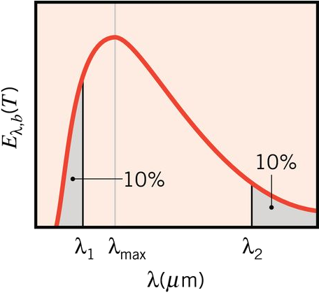

Referring to Table 13.1, the fraction of the radiation being emitted in the first region shows that interpolation is needed. This is shown below.

$$F_A = 0.066728$$
$$F_B = 0.100888$$
$$(\lambda T)_A = 2000\ \mathrm{K} \cdot \mathrm{μm}$$
$$(\lambda T)_B = 2200\ \mathrm{K} \cdot \mathrm{μm}$$
$$(\lambda T)_1 = \frac{F_1 - F_A}{F_B - F_A}[(\lambda T)_B - (\lambda T)_A] + (\lambda T)_A = 2194.8\ \mathrm{K} \cdot \mathrm{μm}$$

Since the product of the wavelength and temperature are now known, the wavelength may be determined by dividing by the temperature. This is shown below.

Answer: $\lambda_1 = \frac{(\lambda T)_1}{T} = 1.097\ \mathrm{μm}$

A similar process is repeated for the second regions. Referring to Table 13.1, the fraction of the radiation being emitted in the second region shows that interpolation is needed. This is shown below.

$$F_A = 0.890029$$
$$F_B = 0.914199$$
$$(\lambda T)_A = 9000\ \mathrm{K} \cdot \mathrm{μm}$$
$$(\lambda T)_B = 10000\ \mathrm{K} \cdot \mathrm{μm}$$
$$(\lambda T)_2 = \frac{F_1 - F_A}{F_B - F_A}[(\lambda T)_B - (\lambda T)_A] + (\lambda T)_A = 9412.5\ \mathrm{K} \cdot \mathrm{μm}$$

Since the product of the wavelength and temperature are now known, the wavelength may be determined by dividing by the temperature. This is shown below.

Answer: $\lambda_2 = \frac{(\lambda T)_2}{T} = 4.706\ \mathrm{μm}$

The wavelength that corresponds to the maximum radiation is given by Wien’s displacement law. Wien’s displacement law says

$$(\lambda T)_{max} = 2898\ \mathrm{K} \cdot \mathrm{μm}$$

Thus the wavelength that corresponds to the maximum radiation is found by

Answer: $\lambda_{max} = \frac{(\lambda T)_{max}}{T} = 1.449\ \mathrm{μm}$

To determine the maximum spectral emissive power, the maximum spectral intensity must first be determined. Referring to Table 13.1, it may be seen in the third column, the following is true at the maximum point.

$$\frac{I_{\lambda,T}(\lambda_{max},T)}{\sigma T^5} = 7.22318\times 10^{-5}\ \frac{1}{\left(\mathrm{K} \cdot \mathrm{μm} \cdot \mathrm{sr}\right)}$$

The maximum spectral intensity is then found by multiplying by the Stefan-Boltzman’s constant and the temperature to the fifth power. This is shown below.

$$I_{\lambda,T}(\lambda_{max}, T) = \frac{I_{\lambda,T} (\lambda_{max},T)}{\sigma T^5}\sigma T^5 = 131.1\ \frac{\mathrm{kW}}{\left(\mathrm{m}^{2} \cdot \mathrm{μm} \cdot \mathrm{sr}\right)}$$

For a diffuse emitter, emissive power may then be determined by

Answer: $E = \pi I_{\lambda,T} = 411.7\ \frac{\mathrm{kW}}{\left(\mathrm{m}^{2} \cdot \mathrm{μm}\right)}$

The irradiation of any small object in the enclosure may be approximated as being equal to the emission from a blackboday at the enclosure surface temperature. Thus

Answer: $G = E_b(T) = \sigma T^4 = 907.2\ \frac{\mathrm{kW}}{\mathrm{m}^{2}}$